Evan Kramer (evankram)

Chase Pasciuto (cpasciut)

# Chapter 4. NumPy Basics: Arrays and Vectorized Computation

- Optimized for working with `array`s
- Stores information in contiguous memory

## 4.2 Universal Functions: Fast Element-Wise Array Functions

- *Ufuncs* return result for each element
- `modf` returns two arrays (whole divisor and remainder)

```python
# Universal functions
import numpy as np
np.random.seed(0)
arr = np.arange(10)
arr
np.sqrt(arr) # takes sqrt of each element
np.exp(arr)
x = np.random.randn(8)
y = np.random.randn(8)
x
y
np.maximum(x, y) # takes the max of each pair
arr = np.random.randn(7) * 5
arr
remainder, whole_part = np.modf(arr) # unpacking
remainder
whole_part
arr
np.sqrt(arr)
np.sqrt(arr, arr) # optional `out` argument
arr

# More ufuncs
arr = np.random.randn(10)
np.abs(arr)
np.fabs(arr)
np.square(arr)
np.exp(arr)
np.log(arr) # can do log2, log10, too
np.sign(arr)
np.ceil(arr) # closest integer greater
np.floor(arr) # lesser
np.rint(arr)
```

```
array([-1.,  2., -1.,  0., -0.,  2.,  1.,  0.,  0., -1.])
```

## 4.3 Array-Oriented Programming

- `meshgrid` can help replace loops with vectors
  - Takes one-dimensional arrays and creates two-dimensional matrices of all pairs of the arrays provided
- `np.where`
  - Arguments (condition, array1, array2)
    - Can also be scalars instead of arrays
  - Much faster than looped alternatives
- Can aggregate with `mean`, `sum`, `std`, etc.
  - Either as an attribute (i.e., `arr.mean`) or function (`np.mean(arr)`)
  - Can specify `axis` argument (results in array with one fewer dimension)
    - `axis = 1` means across columns; `axis = 0` means across rows
- Use `any` and `all` with boolean arrays
  - Recall that 0 and decimals evaluate to `False` and everything else to `True`
- Can `sort` arrays
  - Can also specify dimension to `sort` with `axis` argument
- Return `unique` values
  - Equivalent of `sorted(set(<array>))`
- Check if in list with `in1d`

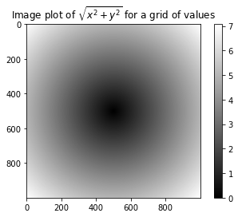

```
array([0., 3., 5.])
```

```python
# Array programming
points = np.arange(-5, 5, 0.01)
xs, ys = np.meshgrid(points, points)
xs
ys
z = np.sqrt(xs ** 2 + ys ** 2) # another way of doing x^2 + y^2 for all pairs
z
import matplotlib.pyplot as plt
plt.imshow(z, cmap = plt.cm.gray); plt.colorbar()
plt.title('Image plot of $\sqrt{x^2 + y^2}$ for a grid of values')
plt.show()

# Conditional logic as array operations
xarr = np.array([1.1, 1.2, 1.3, 1.4, 1.5])
yarr = xarr + 1
cond = np.array([True, False, True, True, False])
result = [(x if c else y) for x, y, c in zip(xarr, yarr, cond)]
result
result = np.where(cond, xarr, yarr)
# %timeit [(x if c else y) for x, y, c in zip(xarr, yarr, cond)]
# %timeit np.where(cond, xarr, yarr) # small difference given how simple the computation is
np.where(xarr > 2, xarr, yarr)

# Example, replace all values with certain other values
arr = np.random.randn(4, 4)
arr
arr > 0
np.where(arr > 0, 2, -2) # replace positive values with 2 and negative values with -2
np.where(arr > 0, 2, arr) # replace all positive values with 2, otherwise same
# np.where(arr > 0) # filters for items above 0

# Math, stats, and aggregations
arr = np.random.randn(5, 4)
arr
arr.mean()
np.mean(arr)
arr.sum()
arr.mean(axis = 1) # mean across columns
arr
arr.sum(axis = 0) # sum across rows
arr = np.array([0, 1, 2, 3, 4, 5, 6, 7])
arr.cumsum() # cumulative sum
arr = np.array([[0,1,2], [3,4,5], [6,7,8]])
arr
arr.cumsum(axis = 0) # cumulative sum by row
arr.cumprod(axis = 1) # cumulative product by column
arr.argmin(axis = 0)

# Boolean arrays
arr = np.random.randn(100)
(arr > 0).sum() # count number of positive values?
np.where(arr == np.max(arr))
bools = np.array([False, False, True, False])
bools.any()
bools.all()
arr = np.random.randn(6)
arr
arr.sort()
arr
arr = np.random.randn(5, 3)
arr
arr.sort(1)
arr
large_arr = np.random.randn(1000)
large_arr.sort()
large_arr[int(0.05 * len(large_arr))] # 5% quantile; need to use int because can't subset with float

# Unique values and other logic
names = np.array(['Bob', 'Joe', 'Will', 'Bob', 'Will', 'Joe', 'Joe'])
np.unique(names)
sorted(set(names))
ints = np.array([3, 3, 3, 2, 2, 1, 1, 4, 4])
np.unique(ints)
values = np.array([6, 0, 0, 3, 2, 5, 6])
np.in1d(values, [2, 3, 6])

# Other tests
x1 = np.ceil(np.random.randn(10) ** 2)
y1 = np.floor(np.random.randn(10) ** 2)
x1; y1
np.intersect1d(x1, y1)
np.union1d(x1, y1)
np.setdiff1d(y1, x1)
np.setdiff1d(x1, y1)
np.setxor1d(x1, y1)
```

## 4.4 File Input and Output

- Read/write data with `np.load` and `np.save`
  - NumPy saves arrays as `.npy` files
  - Save multiple with `np.savez`; compress with `np.savez_compressed`

```python
# Files
arr = np.arange(10)
np.save('some_array', arr) # save file
np.load('some_array.npy') # load same file
np.savez('array_archive.npz', a = arr, b = arr)
arch = np.load('array_archive.npz')
arch['a']
arch['b'] # access b element
np.savez_compressed('arrays_compressed.npz', a = arr, b = arr)
```